# Endterm Exam for CSE2520: Big Data Processing

Burcu Kulahcioglu Ozkan

5 November 2021

## Multiple choice questions (16 questions, 16 pts)

1. The command `ls -l` lists the file `runTests.py` as follows:

   ```
   -rwxr-xr-x 1 alice alice 1728 Nov 21 10:32 runTests.py
   ```

   Which of the following is not correct for the `runTests.py`?

   **A.** The size of the file is 1728 bytes  
   **B.** It can only be written by the user `alice`  
   **C.** It can only be executed by the user `alice`  
   **D.** Its permissions shortcode is *755*
2. Which of the pipelines lists duplicate line (which are repeated more than once) in the file `file.txt` together with the number of their occurrences? We assume that a line cannot be repeated by ten or more times.

   Reminder on the options of `uniq` command:  
   `-c` prefixes lines by the number of occurrences  
   `-d` only prints duplicate lines, one for each group

   **A.** `sort file.txt | uniq -c | sort -n | tr -s ' ' | grep "^ [1-9]* .*"`  
   **B.** `sort file.txt | uniq -c | sort -n | tr -s ' ' | grep "^ [2-9]* .*"`  
   **C.** `sort file.txt | uniq -d | sort -n | tr -s ' ' | grep "^ [1-9]* .*"`  
   **D.** `sort file.txt | uniq -d | sort -n | tr -s ' ' | grep "^ [2-9]* .*"`
3. What do the following lines evaluate?

   ```scala
   val list = List(1,2,3,4)
   val unknown = list.foldRight(Nil:List[Int])(_ :: _)
   ```

   **A.** `List(4, List(3, List(2, List(1))))`  
   **B.** `List(1,2,3,4)`  
   **C.** `List(4,3,2,1)`  
   **D.** `List(1, List(2, List(3, List(4))))`
4. Which Spark RDD function does the following signature correspond to?
   $$RDD[A].f(z: B, op1: (B, A) \rightarrow B, op2: (B, B) \rightarrow B )
   \rightarrow B$$

   **A.** `reduce`  
   **B.** `fold`  
   **C.** `aggregate`  
   **D.** `mapPartitions`
5. Which of the following is **false** about fault-tolerance of Spark?

   **A.** Relies on the immutability of RDDs  
   **B.** Uses RDD lineage to identify what needs to be recomputed  
   **C.** Recomputes DAG to reassign the task of the faulty node  
   **D.** There is no need to restart the whole application from scratch if a worker node fails
6. Choose the correct implementation of the `Monad` interface in Scala:

**A.**

```scala
      trait Monad[M[_]] {
        def unit[S](a: S) : M[S]
        def flatMap[S, T] (m: M[S], f: S => M[T]) : Monad[T]
      }
```

**B.**

```scala
        trait Monad[M[_]] {
          def unit[S](a: S) : M[S]
          def map[T] (m: M[S], f: S => M[T]) : Monad[T]
        }
```

**C.**

```scala
        trait Monad[M[_]] {
          def map[T] (m: M[S], f: S => M[T]) : Monad[T]
          def reduce[T,B](init: B, f: (B,T) => M[B]): Monad[B]
        }
```

**D.**

```scala
        trait Monad[M[_]] {
          def map[T] (m: M[S], f: S => M[T]) : Monad[T]
          def flatMap[S, T] (m: M[S], f: S => M[T]) : T
        }
```

7. Which of the following statements about Spark is **false**?

   **A.** Transformations are not executed until an action is called  
   **B.** `mapValues` is an example of a function that requires shuffling  
   **C.** Allows the programmer to customize the partitioning of pair RDDs  
   **D.** Lazy transformations enable Spark to run more efficiently
8. In a system with 3 nodes A, B, C, six events took place in the following order:
   - Event 1. A sends `msg1` to B
   - Event 2. B sends `msg2` to A
   - Event 3. B receives `msg1`
   - Event 4. A receives `msg2`
   - Event 5. B sends `msg3` to C
   - Event 6. C receives `msg3`

   Which pair of events are not causally related (i.e., they are concurrent) to each other? (You can compute vector clocks for checking causal dependencies.)

   **A.** (Event 2, Event 4)  
   **B.** (Event 3, Event 4)  
   **C.** (Event 3, Event 5)  
   **D.** (Event 3, Event 6)
9. Which of these statements about replication architectures is **false**?

   **A.** With synchronous replication, the write operations cannot be processed if a follower does not respond  
   **B.** Asynchronous replication guarantees that the followers are up-to-date with the leader  
   **C.** Multi-leader replication requires a policy to resolve conflicting write requests  
   **D.** Leaderless replication processes read/write queries based on a quorum of replicas
10. Which of these sentences about the Raft consensus algorithm is **false**?

    **A.** Every Raft term has exactly one leader  
    **B.** Raft defines 2 cluster states: “Leader election” and “Log replication”  
    **C.** Raft ensures that only servers with up-to-date logs can become leader  
    **D.** The Raft algorithm works by assuming that the exchanged messages are valid and true
11. What is *Byzantine fault tolerance*?

    **A.** Resilience against multiple node crashes  
    **B.** Resilience against multiple message losses  
    **C.** Resilience against partitioned network  
    **D.** Resilience against malicious nodes
12. We’re designing a system that replicates a sequence of user commands on a geographically distributed set of nodes. Our system ensures that all previous commands are replicated to all the nodes before processing a new one.

    Given that our system runs on an unreliable network, which of the properties **cannot** always be satisfied by our system?

    **A.** Atomicity  
    **B.** Availability  
    **C.** Consistency  
    **D.** Durability
13. A GFS chunkserver/HDFS datanode is responsible to:

    **A.** Store filesystem path information  
    **B.** Split the data into partitions  
    **C.** Store data partitions  
    **D.** Replicate the data onto multiple disks
14. Which of the following is **false** about Pregel and Bulk synchronization parallel (BSP) model?

    **A.** BSP is an edge-centric approach where the algorithm iterates over the edges  
    **B.** BSP executes in supersteps each of which involves local computation followed by message sending  
    **C.** Supersteps are globally synchronized among all vertices  
    **D.** Pregel is an adaptation of BSP for graph processing
15. An advertisement company wants to monitor the sequence of videos viewed by a registered user in one sitting. What type of streaming windows would be the most suitable to analyze the user behavior?

    **A.** Sliding window  
    **B.** Tumbling window  
    **C.** Global window  
    **D.** Session window
16. What will be produced by the following Flink code snippet:

    ```scala
    dataStream.map(c => (c.id, 1)).keyBy(x => x._1).sum(1)
    ```

    **A.** Stream of the sums per ID  
    **B.** Stream with a single number (the total sum)  
    **C.** Stream of increasing integers  
    **D.** Runtime Exception

## Open-ended questions (3 questions, 7 pts)

1. (**2pts**) The figure below depicts an execution history that operates on a distributed integer variable `x` whose initial value is `0`. The operations in the history are labelled with A-G. Is the given execution history linearizable? If yes, provide a valid linearization. If not, provide an example operation that violates linearizability.

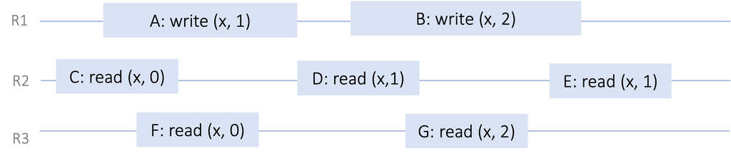

2. (**3pts**) Given the following Spark program, write the **types** of the variables `a`, `b`, and, `c`.

   ```scala
     case class Student(sid: Int, sname: String)
     case class Enrollment(sid: Int, cid: Int)

     val students: RDD[Student] = // reads students from a file into an RDD
     val enrollments: RDD[Enrollment] = // reads enrollments from a file into an RDD

     val a = students.map(s => (s.sid, s.sname))
     val b = enrollments.groupBy(_.sid).mapValues(_.size)
     val c = a.join(b)
   ```

3. (**2pts**) What are wide and narrow transformations in Spark? Describe them with 1-2 sentences and provide an example for each type of transformations.

## Functional programming questions (3 questions, 9 points)

See the FP practice questions in Weblab.